# Script 2 — PP nearshore vs whole region by month

OHI GoC

August 31, 2026

# Overview

**Copernicus Primary Production (PP)** — modeled phytoplankton carbon fixation (mg C m⁻² day⁻¹). Climate / declining-productivity pressure (not eutrophication).

| Item | Path |
| --- | --- |
| Download | `_pressures/prs_npp/script1_download_pp.qmd` |
| Monthly rasters | `/home/shares/ohi/OHI_GOC/_raw_data/npp_copernicus/monthly_rasters/` |
| Zonal table | `/home/shares/ohi/OHI_GOC/goal_prep/pressures/npp/int/` |
| **Standalone PP animations** | `_pressures/prs_npp/html_maps/` — run `script3_build_pp_monthly_maps.R` |

This report compares **whole marine region** vs **5 km nearshore** PP for each OHI region, **one figure per calendar month** (12 sections × 9 region panels).

Analysis window: **2000–2024**.

# Peak months vs annual average — which matters?

Both can be biologically meaningful; they answer different questions.

**Peak / high-production months** (often late spring–summer upwelling in the GoC):

- Drive short-lived **blooms**, fishery recruitment windows, and episodic food supply
- Best if the pressure story is “are the **productive seasons** weakening?”
- Noisier year-to-year (ENSO, upwelling timing)

**Annual mean (or annual sum / integral)**:

- Approximates **total carbon fixed over the year** — closer to the food-web “base”
- Smoother, better for **long-term climate trend** detection
- Standard choice for basin-scale productivity change papers

**Practical recommendation for OHI:** start with **annual mean PP by region** for the pressure score, but use these **monthly nearshore vs whole** plots to see *which months* drive any decline and whether coastal strips differ. If one season (e.g. June–August) shows a clear downward trend everywhere, you may want a **growing-season mean** instead of calendar-year mean — but justify that from these plots, not upfront.

# Setup and data

```r
library(dplyr)
library(tidyr)
library(purrr)
library(ggplot2)
library(RColorBrewer)
library(readr)
library(here)

year_start <- 2000L
year_end   <- 2024L
nearshore_km  <- 5L
nearshore_tag <- sprintf("%dkm", nearshore_km)

dir_int <- "/home/shares/ohi/OHI_GOC/goal_prep/pressures/npp/int"
zonal_csv <- file.path(
  dir_int,
  sprintf("pp_zonal_mean_by_region_month_%d_%d.csv", year_start, year_end)
)

nearshore_label <- sprintf("Nearshore %s", nearshore_tag)
series_colors <- c("Whole region" = "#2166ac")
series_colors[nearshore_label] <- "#b2182b"

stopifnot(file.exists(zonal_csv))
zonal_long <- read.csv(zonal_csv, stringsAsFactors = FALSE) %>%
  mutate(
    month_lab = factor(month, levels = 1:12, labels = month.abb),
    rgn_id = factor(rgn_id, levels = paste0("Region_", 1:9))
  )

z_whole <- filter(zonal_long, zone == "whole")
z_near  <- filter(zonal_long, zone == sprintf("nearshore_%s", nearshore_tag))

region_colors <- setNames(
  brewer.pal(9, "Set1"),
  paste0("Region_", 1:9)
)

# Annual mean PP = mean of all 12 monthly regional means within each year
annual_region <- z_whole %>%
  group_by(rgn_id, year) %>%
  summarize(
    pp_annual = mean(pp_mean, na.rm = TRUE),
    n_months  = sum(!is.na(pp_mean)),
    .groups   = "drop"
  )

fit_annual_trend <- function(df) {
  fit <- lm(pp_annual ~ year, data = df)
  co <- summary(fit)$coefficients
  tibble(
    slope_mg_yr   = unname(coef(fit)[2]),
    intercept     = unname(coef(fit)[1]),
    p_value       = co[2, 4],
    r_squared     = summary(fit)$r.squared,
    mean_2000_2004 = mean(df$pp_annual[df$year <= 2004], na.rm = TRUE),
    mean_2019_2024 = mean(df$pp_annual[df$year >= 2019], na.rm = TRUE)
  )
}

annual_trends <- annual_region %>%
  group_by(rgn_id) %>%
  group_modify(~ fit_annual_trend(.x)) %>%
  ungroup() %>%
  mutate(
    change_recent_minus_early = mean_2019_2024 - mean_2000_2004,
    pct_change_per_yr = 100 * slope_mg_yr / mean_2000_2004,
    trend = case_when(
      p_value < 0.05 & slope_mg_yr < 0 ~ "Declining (p < 0.05)",
      p_value < 0.05 & slope_mg_yr > 0 ~ "Increasing (p < 0.05)",
      TRUE ~ "Not significant"
    )
  )

plot_nearshore_vs_whole <- function(month_num) {
  compare <- bind_rows(
    mutate(filter(z_whole, month == month_num), series = "Whole region"),
    mutate(filter(z_near, month == month_num), series = nearshore_label)
  )

  ggplot(compare, aes(year, pp_mean, color = series)) +
    geom_line(linewidth = 0.7) +
    geom_point(size = 1.1, alpha = 0.85) +
    facet_wrap(~ rgn_id, ncol = 3, scales = "free_y") +
    scale_color_manual(values = series_colors, name = NULL) +
    scale_x_continuous(breaks = seq(year_start, year_end, by = 5)) +
    labs(
      title = sprintf("%s — PP: whole region vs %d km nearshore", month.name[month_num], nearshore_km),
      subtitle = sprintf("OHI marine regions, %d–%d", year_start, year_end),
      x = "Year",
      y = "Mean PP (mg C m⁻² day⁻¹)"
    ) +
    theme_minimal(base_size = 11) +
    theme(
      legend.position = "bottom",
      strip.text = element_text(face = "bold")
    )
}
```

# Regional annual mean PP (whole marine zone)

For each OHI region and year, **annual mean PP** is the average of that region’s 12 monthly mean values (Jan–Dec). This smooths within-year seasonality and is the best first look at longer-term change.

## Annual mean through time — all regions

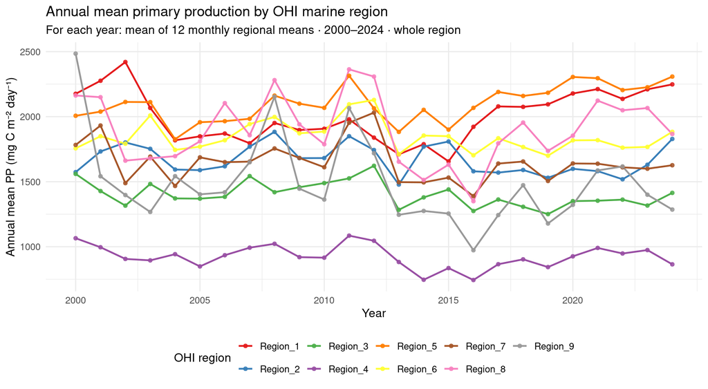

```r
ggplot(annual_region, aes(year, pp_annual, color = rgn_id)) +
  geom_line(linewidth = 0.85) +
  geom_point(size = 1.5, alpha = 0.85) +
  scale_color_manual(values = region_colors, name = "OHI region") +
  scale_x_continuous(breaks = seq(year_start, year_end, by = 5)) +
  labs(
    title = "Annual mean primary production by OHI marine region",
    subtitle = sprintf(
      "For each year: mean of 12 monthly regional means · %d–%d · whole region",
      year_start, year_end
    ),
    x = "Year",
    y = "Annual mean PP (mg C m⁻² day⁻¹)"
  ) +
  theme_minimal(base_size = 12) +
  theme(legend.position = "bottom")
```

## One panel per region (with linear trend)

Solid points/lines = annual means. Blue line = **ordinary least squares** regression of annual mean PP on year (2000–2024).

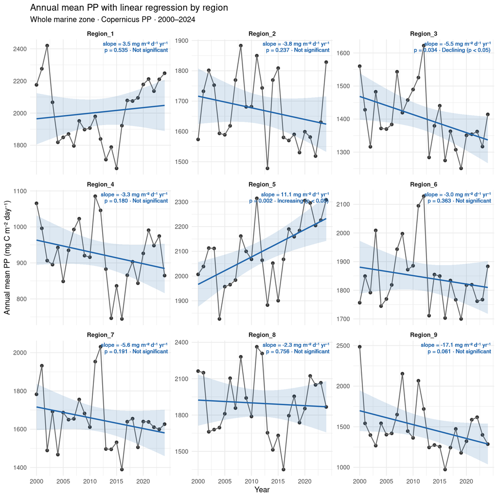

```r
annual_trends_joined <- annual_region %>%
  left_join(
    annual_trends %>% select(rgn_id, slope_mg_yr, intercept, p_value, trend),
    by = "rgn_id"
  ) %>%
  mutate(
    label = sprintf(
      "slope = %.1f mg m⁻² d⁻¹ yr⁻¹\np = %.3f · %s",
      slope_mg_yr, p_value, trend
    )
  )

ggplot(annual_trends_joined, aes(year, pp_annual)) +
  geom_point(size = 1.8, color = "#333333") +
  geom_line(linewidth = 0.6, color = "#666666") +
  geom_smooth(
    method = "lm",
    se = TRUE,
    linewidth = 0.9,
    color = "#2166ac",
    fill = "#2166ac",
    alpha = 0.15
  ) +
  geom_text(
    aes(label = label),
    x = Inf, y = Inf,
    hjust = 1.05, vjust = 1.2,
    size = 2.8,
    lineheight = 0.95,
    color = "#2166ac"
  ) +
  facet_wrap(~ rgn_id, ncol = 3, scales = "free_y") +
  scale_x_continuous(breaks = seq(year_start, year_end, by = 5)) +
  labs(
    title = "Annual mean PP with linear regression by region",
    subtitle = "Whole marine zone · Copernicus PP · 2000–2024",
    x = "Year",
    y = "Annual mean PP (mg C m⁻² day⁻¹)"
  ) +
  theme_minimal(base_size = 11) +
  theme(strip.text = element_text(face = "bold"))
```

## Regression summary table

Linear model: `pp_annual ~ year` for each region (25 years).

```r
knitr::kable(
  annual_trends %>%
    select(
      rgn_id,
      slope_mg_yr,
      p_value,
      r_squared,
      mean_2000_2004,
      mean_2019_2024,
      change_recent_minus_early,
      pct_change_per_yr,
      trend
    ) %>%
    arrange(slope_mg_yr),
  digits = 3,
  col.names = c(
    "Region",
    "Slope (mg m⁻² d⁻¹ yr⁻¹)",
    "p-value",
    "R²",
    "Mean 2000–2004",
    "Mean 2019–2024",
    "Recent − early",
    "% change yr⁻¹ (vs early mean)",
    "Trend"
  ),
  caption = "Regional regression of annual mean PP on year (2000–2024)"
)
```

Regional regression of annual mean PP on year (2000–2024)

| Region | Slope (mg m⁻² d⁻¹ yr⁻¹) | p-value | R² | Mean 2000–2004 | Mean 2019–2024 | Recent − early | % change yr⁻¹ (vs early mean) | Trend |
| --- | --- | --- | --- | --- | --- | --- | --- | --- |
| Region_9 | -17.076 | 0.061 | 0.145 | 1646.796 | 1398.465 | -248.331 | -1.037 | Not significant |
| Region_7 | -5.644 | 0.191 | 0.073 | 1672.686 | 1603.485 | -69.201 | -0.337 | Not significant |
| Region_3 | -5.479 | 0.034 | 0.181 | 1431.629 | 1341.370 | -90.259 | -0.383 | Declining (p < 0.05) |
| Region_2 | -3.841 | 0.237 | 0.060 | 1690.726 | 1614.658 | -76.068 | -0.227 | Not significant |
| Region_4 | -3.284 | 0.180 | 0.077 | 961.161 | 924.671 | -36.491 | -0.342 | Not significant |
| Region_6 | -2.952 | 0.363 | 0.036 | 1830.287 | 1791.595 | -38.691 | -0.161 | Not significant |
| Region_8 | -2.295 | 0.756 | 0.004 | 1870.118 | 1949.387 | 79.270 | -0.123 | Not significant |
| Region_1 | 3.472 | 0.535 | 0.017 | 2151.400 | 2179.972 | 28.572 | 0.161 | Not significant |
| Region_5 | 11.089 | 0.002 | 0.355 | 2019.390 | 2253.840 | 234.450 | 0.549 | Increasing (p < 0.05) |

**Gulf-wide check** (unweighted mean of the 9 regional annual means each year):

```r
gulf_annual <- annual_region %>%
  group_by(year) %>%
  summarize(pp_annual = mean(pp_annual), .groups = "drop")

fit_gulf <- lm(pp_annual ~ year, data = gulf_annual)
gulf_slope <- coef(fit_gulf)[2]
gulf_p     <- summary(fit_gulf)$coefficients[2, 4]

knitr::kable(
  tibble(
    Metric = c(
      "Slope (mg m⁻² d⁻¹ yr⁻¹)",
      "p-value",
      "R²",
      "Mean 2000–2004",
      "Mean 2019–2024"
    ),
    Value = c(
      sprintf("%.2f", gulf_slope),
      sprintf("%.4f", gulf_p),
      sprintf("%.3f", summary(fit_gulf)$r.squared),
      sprintf("%.1f", mean(gulf_annual$pp_annual[gulf_annual$year <= 2004])),
      sprintf("%.1f", mean(gulf_annual$pp_annual[gulf_annual$year >= 2019]))
    )
  ),
  caption = "Gulf-wide annual mean PP regression (average of 9 regions per year)"
)
```

Gulf-wide annual mean PP regression (average of 9 regions per year)

| Metric | Value |
| --- | --- |
| Slope (mg m⁻² d⁻¹ yr⁻¹) | -2.89 |
| p-value | 0.3768 |
| R² | 0.034 |
| Mean 2000–2004 | 1697.1 |
| Mean 2019–2024 | 1673.0 |

# Monthly comparisons (whole region vs 5 km nearshore)

Solid blue = whole region. Red = 5 km nearshore band. Each panel is one OHI marine region. Open **year-by-year GIF animations** in `_pressures/prs_npp/html_maps/index.html` (run `script3_build_pp_monthly_maps.R`).

```r
for (m in 1:12) {
  cat("\n\n## ", month.name[m], "\n\n")
  print(plot_nearshore_vs_whole(m))
}
```

## January

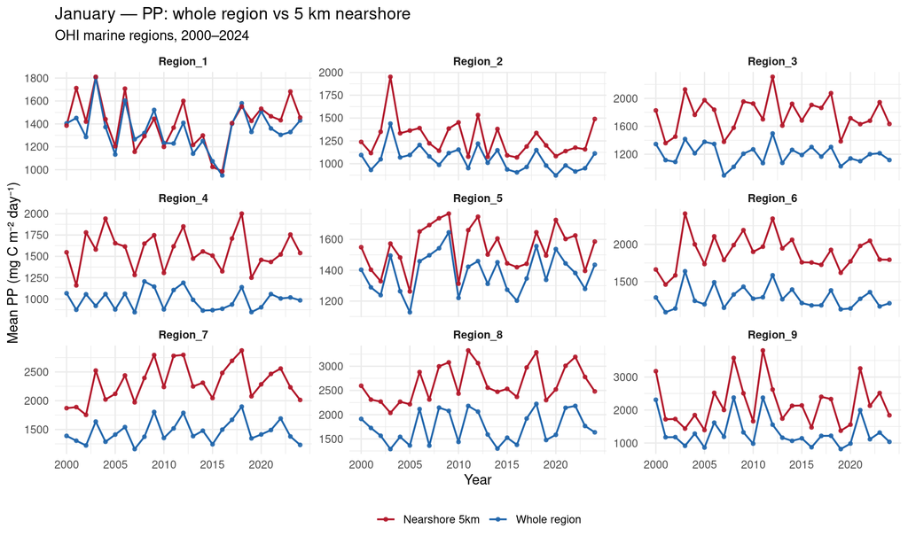

## February

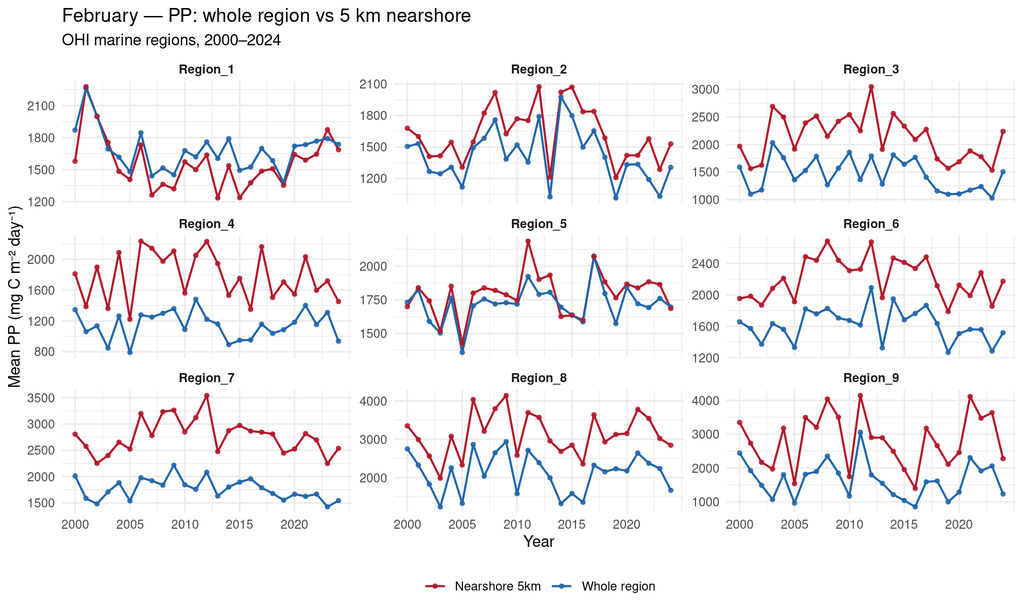

## March

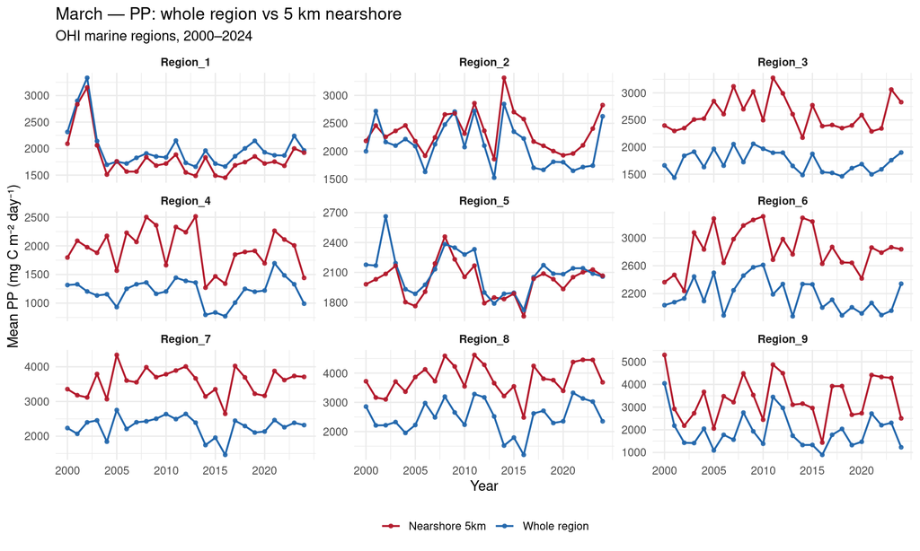

## April

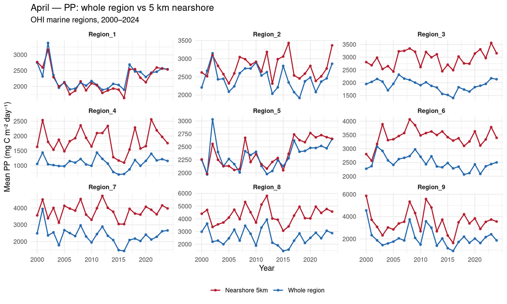

## May

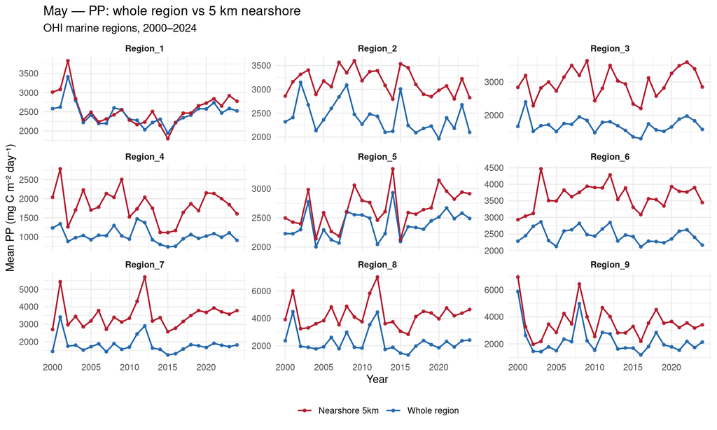

## June

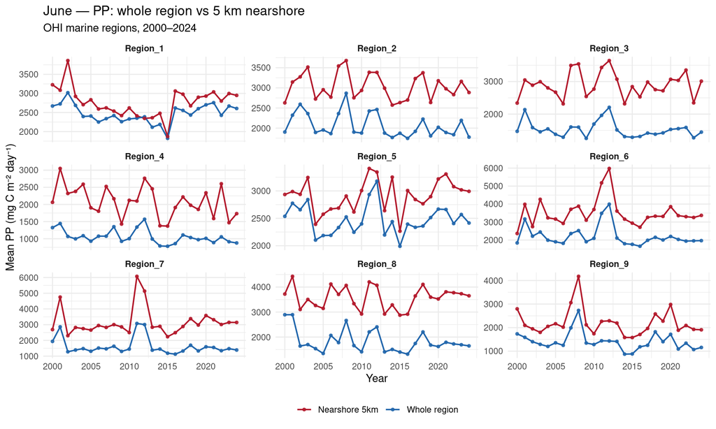

## July

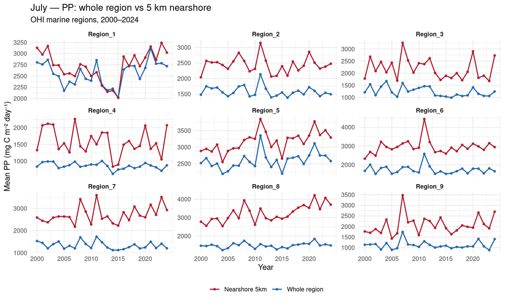

## August

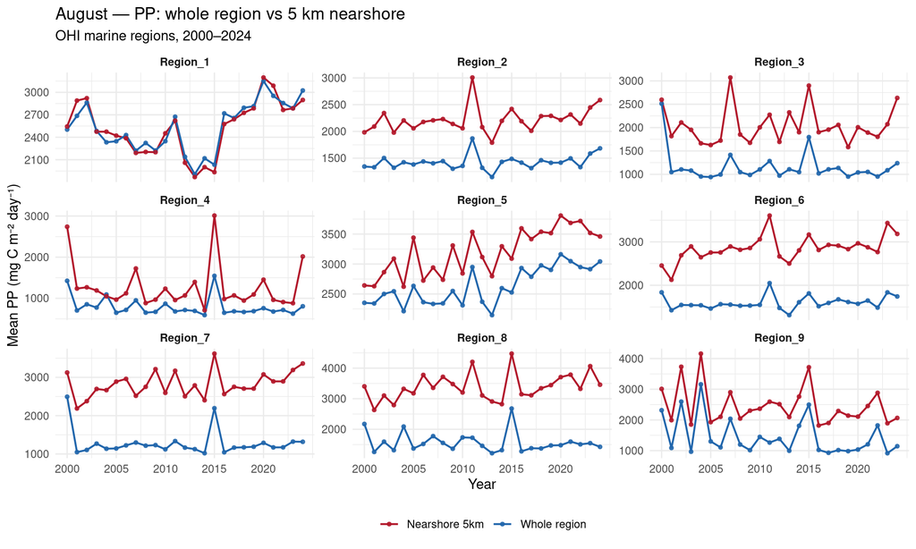

## September

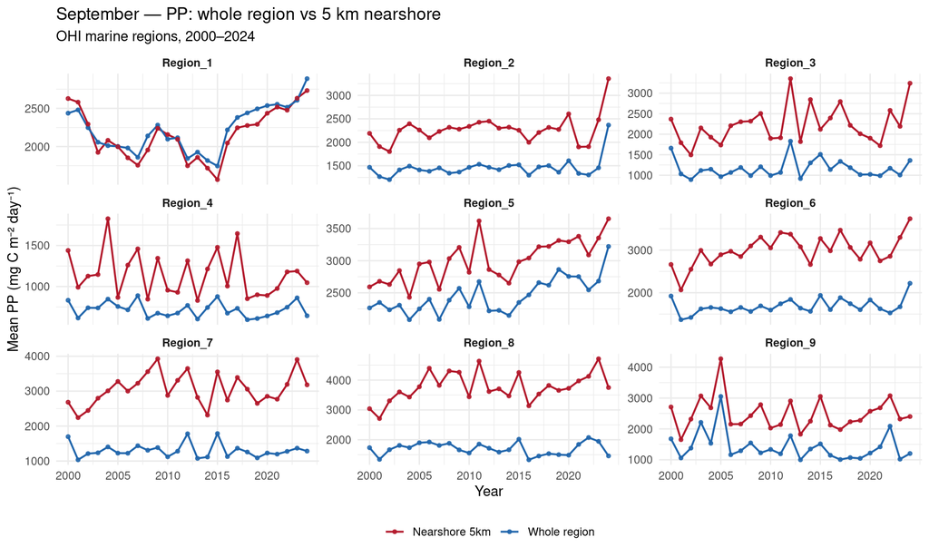

## October

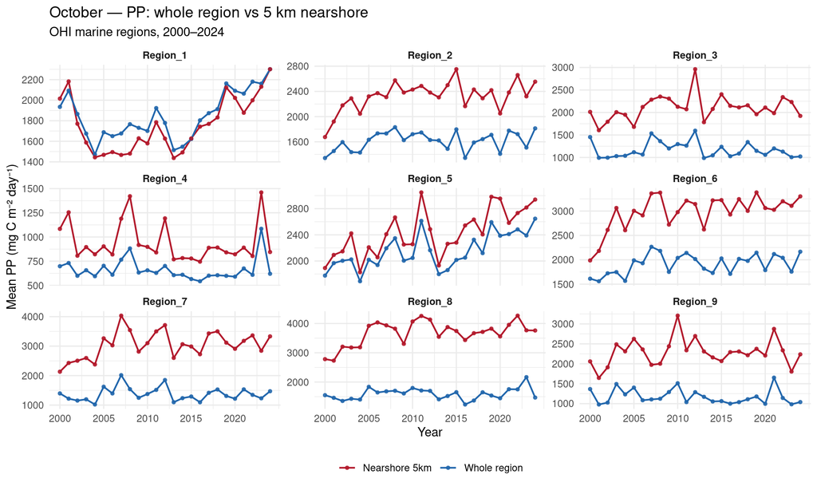

## November

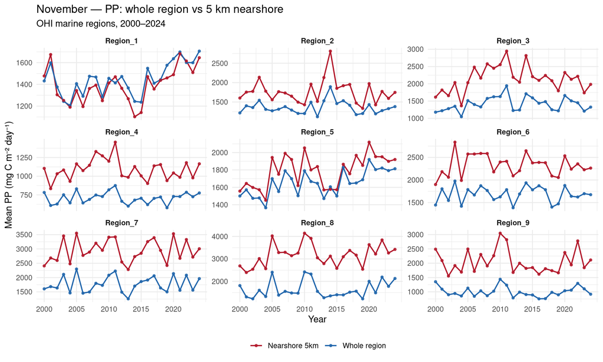

## December

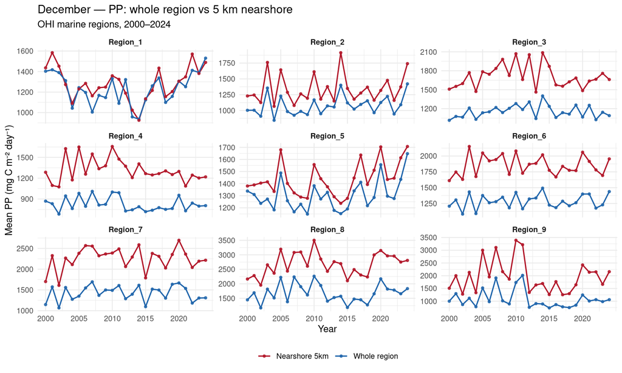

# Decision: `climate_npp_loss` pressure (all regions = 0)

After exploration of regional annual-mean patterns (2000–2024) and monthly comparisons we **do not believe NPP is declining** for any OHI marine region.

**Why every region receives pressure = 0:**

1. **No gulf-wide signal** — the mean of regional annual PP shows a slight negative slope but **p ≈ 0.38** (not significant).
2. **Only one borderline region** — Region_3 (Central Gulf, BCS) has the only annual trend with **p < 0.05** (p ≈ 0.034), but that result is **fragile** (not significant if the series starts in 2011) and is **not robust to multiple comparisons** across nine regions (and many monthly tests).

This pressure is **documented and scored as zero** for 2024. If future years or alternative PP products show robust declines, the rule can be revisited. Montly and yearly variation in NPP is high, making long term declines difficult to identify.

```r
library(readr)

out_dir <- here("_pressures", "prs_npp", "output")
dir.create(out_dir, showWarnings = FALSE, recursive = TRUE)

climate_npp_loss <- tibble(
  indicator = "climate_npp_loss",
  year = 2024L,
  rgn_id = paste0("Region_", 1:9),
  pressure = 0
)

out_file <- file.path(out_dir, "climate_npp_loss.csv")
write_csv(climate_npp_loss, out_file)

knitr::kable(
  climate_npp_loss,
  caption = sprintf("Saved to %s", out_file)
)
```

Saved to /home/frazier/ohi_goc_prep/_pressures/prs_npp/output/climate_npp_loss.csv

| indicator | year | rgn_id | pressure |
| --- | --- | --- | --- |
| climate_npp_loss | 2024 | Region_1 | 0 |
| climate_npp_loss | 2024 | Region_2 | 0 |
| climate_npp_loss | 2024 | Region_3 | 0 |
| climate_npp_loss | 2024 | Region_4 | 0 |
| climate_npp_loss | 2024 | Region_5 | 0 |
| climate_npp_loss | 2024 | Region_6 | 0 |
| climate_npp_loss | 2024 | Region_7 | 0 |
| climate_npp_loss | 2024 | Region_8 | 0 |
| climate_npp_loss | 2024 | Region_9 | 0 |